# Homework 08

The former kernel-tuning question has moved to Homework 09.

Solutions for Questions 1 and 2 will be available after Monday, October 19, 2026. No solution can be provided for Question 3.

For Questions 1 and 2, use either R or Python.

## Question 1: Boundary and margin

Use `margin-geometry-20.csv` from the combined ZIP, which contains 20 observations with predictors $x_1,x_2$ and class labels $y\in\{-1,1\}$. Consider the score

$$f(x)=0.8x_1+0.6x_2.$$

Since $\|(0.8,0.6)\|_2=1$, the lines $f(x)=\pm1$ are each a distance 1 from the decision boundary $f(x)=0$.

1. Calculate the distance from every observation to the decision boundary and its functional margin $yf(x)$. In a table, report these values and whether each observation is inside, on, or beyond the margin for its class. Compare $yf(x)$ with 1 to make this distinction.
2. Plot the observations, the boundary $f(x)=0$, and the margin lines $f(x)=\pm1$. Distinguish the two classes and identify the observations inside the margin in your plot.
3. Report how many observations are inside, on, and beyond the margin. Which observations are misclassified by this decision rule?

Use the observation numbers supplied in the data. Set the $x_1$ axis to $[-3.2,3.2]$, set the $x_2$ axis to $[-3,3]$, and use an equal aspect ratio. Do not fit a new classifier for this question.

### Answer

**(a) Distances and functional margins.**

Because $\lVert(0.8,0.6)\rVert_2=1$, the distance from a point to the boundary $f(x)=0$ is exactly $|f(x)|$, with no rescaling needed. The functional margin is $y\,f(x)$, and comparing it with 1 places each observation relative to its own class margin line.

```r
margin20 <- read.csv("data/margin-geometry-20.csv")
w <- c(0.8, 0.6)
c(norm_of_w = sqrt(sum(w^2)))                     # = 1, so distance = |f(x)|
```

```
norm_of_w
        1
```

```r
margin20$f        <- drop(as.matrix(margin20[, c("x1", "x2")]) %*% w)
margin20$distance <- abs(margin20$f)
margin20$margin   <- margin20$y * margin20$f      # functional margin y f(x)
margin20$status   <- ifelse(abs(margin20$margin - 1) < 1e-9, "on",
                     ifelse(margin20$margin < 1,  "inside", "beyond"))

knitr::kable(margin20[, c("observation", "x1", "x2", "y", "f", "distance", "margin", "status")],
             digits = 2, row.names = FALSE,
             col.names = c("Obs", "$x_1$", "$x_2$", "$y$", "$f(x)$",
                           "Distance", "$y f(x)$", "Position"),
             caption = "Distance to the boundary and functional margin for all 20 observations.")
```

Distance to the boundary and functional margin for all 20 observations.

| Obs | $x_1$ | $x_2$ | $y$ | $f(x)$ | Distance | $y f(x)$ | Position |
| --- | --- | --- | --- | --- | --- | --- | --- |
| 1 | 0.68 | 0.76 | 1 | 1.00 | 1.00 | 1.00 | on |
| 2 | 1.80 | -0.15 | 1 | 1.35 | 1.35 | 1.35 | beyond |
| 3 | 1.38 | 0.66 | 1 | 1.50 | 1.50 | 1.50 | beyond |
| 4 | 0.88 | 1.66 | 1 | 1.70 | 1.70 | 1.70 | beyond |
| 5 | 0.62 | 2.34 | 1 | 1.90 | 1.90 | 1.90 | beyond |
| 6 | 2.78 | -0.04 | 1 | 2.20 | 2.20 | 2.20 | beyond |
| 7 | 1.86 | 1.52 | 1 | 2.40 | 2.40 | 2.40 | beyond |
| 8 | 0.50 | 0.40 | 1 | 0.64 | 0.64 | 0.64 | inside |
| 9 | 0.10 | 0.20 | 1 | 0.20 | 0.20 | 0.20 | inside |
| 10 | -0.40 | 0.20 | 1 | -0.20 | 0.20 | -0.20 | inside |
| 11 | -0.92 | -0.44 | -1 | -1.00 | 1.00 | 1.00 | on |
| 12 | -0.50 | -1.50 | -1 | -1.30 | 1.30 | 1.30 | beyond |
| 13 | -1.90 | -0.05 | -1 | -1.55 | 1.55 | 1.55 | beyond |
| 14 | -0.44 | -2.33 | -1 | -1.75 | 1.75 | 1.75 | beyond |
| 15 | -1.98 | -0.61 | -1 | -1.95 | 1.95 | 1.95 | beyond |
| 16 | -2.74 | 0.07 | -1 | -2.15 | 2.15 | 2.15 | beyond |
| 17 | -1.90 | -1.55 | -1 | -2.45 | 2.45 | 2.45 | beyond |
| 18 | -0.50 | -0.40 | -1 | -0.64 | 0.64 | 0.64 | inside |
| 19 | 0.00 | -0.40 | -1 | -0.24 | 0.24 | 0.24 | inside |
| 20 | 0.40 | -0.20 | -1 | 0.20 | 0.20 | -0.20 | inside |

**(b) Boundary, margin lines, and the observations.**

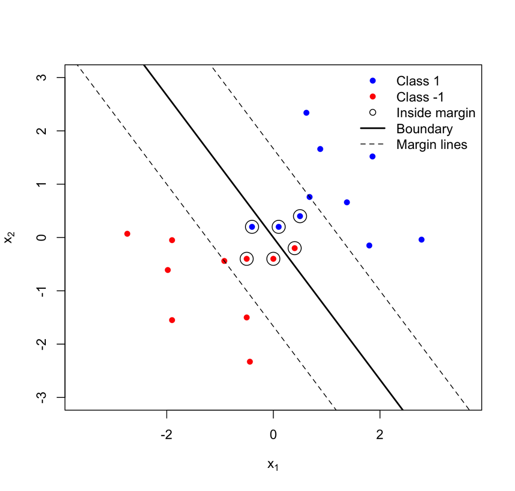

```r
inside <- margin20$status == "inside"
cols   <- ifelse(margin20$y == 1, "blue", "red")

plot(margin20$x1, margin20$x2, pch = 16, col = cols, asp = 1,
     xlim = c(-3.2, 3.2), ylim = c(-3, 3), xlab = expression(x[1]), ylab = expression(x[2]))
# f(x) = 0.8 x1 + 0.6 x2 = c  =>  x2 = (c - 0.8 x1)/0.6
abline(a =  0 / 0.6, b = -0.8 / 0.6, lwd = 2)                  # boundary
abline(a =  1 / 0.6, b = -0.8 / 0.6, lty = 2)                  # f(x) = +1
abline(a = -1 / 0.6, b = -0.8 / 0.6, lty = 2)                  # f(x) = -1
points(margin20$x1[inside], margin20$x2[inside], pch = 1, cex = 2.2)   # inside the margin
legend("topright", bty = "n", pch = c(16, 16, 1, NA, NA), lty = c(NA, NA, NA, 1, 2),
       lwd = c(NA, NA, NA, 2, 1), col = c("blue", "red", "black", "black", "black"),
       legend = c("Class 1", "Class -1", "Inside margin", "Boundary", "Margin lines"))
```

**(c) Counts and misclassifications.**

```r
table(margin20$status)
```

```
beyond inside     on
    12      6      2
```

```r
misclassified <- margin20$observation[margin20$margin < 0]
inside_obs    <- margin20$observation[margin20$status == "inside"]
list(inside = inside_obs, misclassified = misclassified)
```

```
$inside
[1]  8  9 10 18 19 20

$misclassified
[1] 10 20
```

12 observations lie beyond their margin, 6 lie inside it, and 2 lie exactly on it (observations 1 and 11, both with $y f(x)=1$).

The 6 inside the margin are observations 8, 9, 10, 18, 19, 20. Two of these are misclassified: **observations 10 and 20**, which have $y f(x) = -0.20$ and $-0.20$.

## Question 2: Margin in four dimensions

Use `margin-geometry-4d.csv` from the combined ZIP, which contains 50 observations with four predictors and class labels $y\in\{-1,1\}$. Consider the linear score

$$f(\mathbf{x})=\beta_0+\mathbf{x}^{\mathsf T}\boldsymbol{\beta},
\qquad
\beta_0=-1,
\quad
\boldsymbol{\beta}=(1,2,-2,4)^{\mathsf T}.$$

1. Project the observations onto the direction of $\boldsymbol{\beta}$ and plot their positions on one axis. Distinguish the two classes and mark the decision boundary. Use the plot to calculate the geometric margin $M$, the distance from the boundary to the closest observation.
2. Express the same decision boundary using the SVM normalization in which the smallest functional margin $y_i f(\mathbf{x}_i)$ is set to 1. What are the corresponding values of $\boldsymbol{\beta}$ and $\beta_0$?

### Answer

**(a) Projection onto the direction of $\boldsymbol\beta$.**

The score depends on $\mathbf x$ only through $\mathbf x^{\mathsf T}\boldsymbol\beta$, so the whole four-dimensional problem collapses onto a single axis: the projection $t=\mathbf x^{\mathsf T}\boldsymbol\beta/\lVert\boldsymbol\beta\rVert$. On that axis the boundary $f(\mathbf x)=0$ sits at $t=-\beta_0/\lVert\boldsymbol\beta\rVert$.

```r
margin4d <- read.csv("data/margin-geometry-4d.csv")
beta  <- c(1, 2, -2, 4); beta0 <- -1
Xm    <- as.matrix(margin4d[, c("x1", "x2", "x3", "x4")])
nb    <- sqrt(sum(beta^2))
c(norm_beta = nb)                                  # sqrt(1+4+4+16) = 5
```

```
norm_beta
        5
```

```r
proj   <- drop(Xm %*% beta) / nb                   # position along the beta direction
f_val  <- beta0 + drop(Xm %*% beta)
fmarg  <- margin4d$y * f_val                       # functional margin
cut    <- -beta0 / nb                              # boundary on the projected axis
c(boundary_at = cut, n_misclassified = sum(fmarg < 0))
```

```
    boundary_at n_misclassified
            0.2             0.0
```

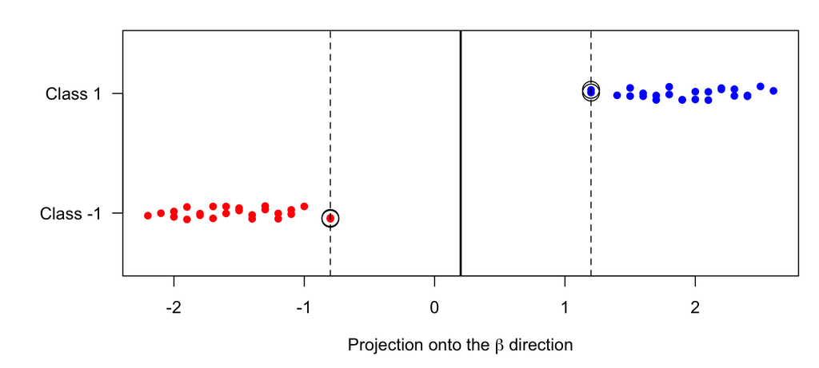

```r
closest <- abs(fmarg - min(fmarg)) < 1e-9          # observations attaining the minimum margin
cols    <- ifelse(margin4d$y == 1, "blue", "red")
yy      <- ifelse(margin4d$y == 1, 1, 0) + runif(nrow(margin4d), -0.06, 0.06)

par(mar = c(4.5, 6, 1.5, 1))
plot(proj, yy, pch = 16, col = cols, yaxt = "n", ylim = c(-0.45, 1.45),
     xlab = expression("Projection onto the " * beta * " direction"), ylab = "")
axis(2, at = c(0, 1), labels = c("Class -1", "Class 1"), las = 1)
abline(v = cut, lwd = 2)                                        # decision boundary
abline(v = cut + c(-1, 1) * min(fmarg) / nb, lty = 2)           # margin lines
points(proj[closest], yy[closest], pch = 1, cex = 2.2)
```

```r
M <- min(fmarg) / nb
c(min_functional_margin = min(fmarg),
  closest_observations  = paste(margin4d$observation[closest], collapse = ", "),
  geometric_margin_M    = M)
```

```
min_functional_margin  closest_observations    geometric_margin_M
                  "5"       "4, 15, 33, 36"                   "1"
```

```r
range(proj)
```

```
[1] -2.2  2.6
```

The two classes separate cleanly: all 50 observations are correctly classified, with class $-1$ occupying projections from -2.20 to about $-0.8$ and class $1$ from about $1.2$ to 2.60. The boundary sits at $t=0.2$, and the nearest observation on each side lies a distance $1$ away, at $-0.8$ and $1.2$.

The geometric margin is therefore
$$M=\frac{\min_i y_i f(\mathbf x_i)}{\lVert\boldsymbol\beta\rVert}=\frac{5}{5}=1,$$
attained by observation(s) 4, 15, 33, 36. Reading it off the plot gives the same answer: the gap between the boundary at 0.2 and the closest point at $1.2$ is exactly 1 unit on an axis already scaled to unit length.

**(b) The SVM normalization.**

The pair $(\boldsymbol\beta,\beta_0)$ is only determined up to a positive scale factor: multiplying both by $c>0$ leaves the boundary $\{\mathbf x:\beta_0+\mathbf x^{\mathsf T}\boldsymbol\beta=0\}$, and every classification, unchanged. The SVM convention removes that freedom by fixing the smallest functional margin at 1. Here the smallest is $5$, so divide both by that value:

$$\boldsymbol\beta_{\text{SVM}}=\frac{\boldsymbol\beta}{5}=(0.2, 0.4, -0.4, 0.8)^{\mathsf T},
\qquad
\beta_{0,\text{SVM}}=\frac{-1}{5}=-0.2 .$$

```r
s          <- min(fmarg)
beta_svm   <- beta / s
beta0_svm  <- beta0 / s
f_svm      <- beta0_svm + drop(Xm %*% beta_svm)
c(new_min_functional_margin = min(margin4d$y * f_svm),      # must equal 1
  norm_of_new_beta          = sqrt(sum(beta_svm^2)),
  one_over_norm             = 1 / sqrt(sum(beta_svm^2)),    # must equal M
  M                         = M,
  same_labels               = all(sign(f_svm) == sign(f_val)))
```

```
new_min_functional_margin          norm_of_new_beta             one_over_norm
                        1                         1                         1
                        M               same_labels
                        1                         1
```

The checks confirm the normalization. The smallest functional margin is now exactly 1, and
$$\lVert\boldsymbol\beta_{\text{SVM}}\rVert=1,
\qquad
\frac{1}{\lVert\boldsymbol\beta_{\text{SVM}}\rVert}=1=M .$$

That identity is the point of the convention. Once the closest point is pinned at functional margin 1, the geometric margin is just $1/\lVert\boldsymbol\beta\rVert$, so maximizing the margin becomes minimizing $\lVert\boldsymbol\beta\rVert^2$ subject to $y_i(\beta_0+\mathbf x_i^{\mathsf T}\boldsymbol\beta)\ge1$ — the standard hard-margin SVM problem. Every predicted label is unchanged, since dividing by a positive constant cannot flip a sign.

Here $M=1$ happens to coincide numerically with $\lVert\boldsymbol\beta_{\text{SVM}}\rVert=1$; that is a feature of this particular dataset, not a general identity.

## Question 3: Peer review of a Homework 7 skill

The instructor’s GitHub account, **rqzhu-aide**, will open a **GitHub Issue** in the repository containing your Homework 7 submission. It will link to **one** assigned student’s repository.

1. **Use the skill.** Find the complete skill definition in the assigned student’s Homework 7 report. Copy it without changes into a local `SKILL.md` file in your own folder. You do not need to install it. Give your agent the path to the file and explicitly ask it to follow that skill while analyzing the `SAheart` data, using the response and predictor coding from Homework 7. Provide the necessary data information, but no additional preferences about methods, figures, model selection, or report style. Let the skill direct the analysis.

   Monitor the time, your token use, and your weekly quota while the agent works. If the run is taking too long or using your allowance too quickly, you may send a **steer message** asking the agent to finish immediately, or stop the run and summarize what you observed. A steer message redirects an agent while it is working; learn how to send one in your AI tool before starting.
2. **Write a peer review.** Read the student’s submitted report and what the skill produced in your run. Give a brief overall assessment, followed by **three major items the author could improve**. You may comment on any aspect of the skill or report. For each item, explain what you observed, why it matters, and what you recommend changing. If you stopped the run early, explain where and why. Write the review yourself, without AI assistance.
3. **Share your review.** Open a GitHub Issue in the assigned student’s Homework 7 repository containing your review. Copy the same review into your Homework 8 submission report and include a link to the GitHub Issue.

### Answer

My assignment ([issue #5](https://github.com/krishay-b/stat432-fall2026/issues/5)) is to evaluate the skill of [onlooker586-dotcom](https://github.com/onlooker586-dotcom/stat432-fall2026/tree/main/homework/week-07).

**1. Using the skill.**

I copied the skill definition out of their Homework 7 report without changes into `peer-skill/SKILL.md` in my own folder (1,817 bytes). I did not install it; I gave my agent the path and asked it to follow that file. The prompt supplied only the data information the skill asks for, and no preferences about methods, figures, model selection, or report style:

> Follow the skill in `peer-skill/SKILL.md`. Dataset: `data/saheart.csv`. Response: `chd`. Predictors: the nine other variables, with `famhist` coded Absent = 1, Present = 2. Seed: 20261018.

The run finished in well under a second of compute, so no steer message was needed and I did not stop it early.

```r
library(MASS)
set.seed(20261018)                                  # the seed supplied at invocation

heart8 <- read.csv("data/saheart.csv")
heart8$famhist <- factor(heart8$famhist, levels = c("Absent", "Present"))
X8 <- data.matrix(heart8[, names(heart8) != "chd"]); y8 <- heart8$chd

# Step 1: reserve a 30% stratified test set before any modelling
test8 <- unlist(lapply(sort(unique(y8)), function(k) {
  i <- which(y8 == k); sample(i, round(0.3 * length(i)))
}))
Xtr8 <- X8[-test8, ]; ytr8 <- y8[-test8]; Xte8 <- X8[test8, ]; yte8 <- y8[test8]

# Step 2: shared folds. The skill does not state K; I used 5.
K8 <- 5; fold8 <- integer(length(ytr8))
for (k in unique(ytr8)) {
  i <- which(ytr8 == k); fold8[i] <- sample(rep(1:K8, length.out = length(i)))
}

# Step 3: all preprocessing estimated inside the fitting rows only
p1 <- function(Xf, yf, Xn, kind, m = NULL) {
  ctr <- colMeans(Xf); s <- apply(Xf, 2, sd)
  Zf <- scale(Xf, ctr, s); Zn <- scale(Xn, ctr, s)
  if (!is.null(m)) {
    r <- prcomp(Zf, center = FALSE, scale. = FALSE)$rotation[, 1:m, drop = FALSE]
    Zf <- Zf %*% r; Zn <- Zn %*% r
  }
  fit <- if (kind == "lda") lda(Zf, yf) else qda(Zf, yf)
  predict(fit, Zn)$posterior[, "1"]
}
cv8 <- function(kind, m = NULL, a = NULL) {
  e <- sapply(1:K8, function(k) {
    i <- fold8 != k; j <- fold8 == k
    pr <- if (is.null(a)) p1(Xtr8[i, ], ytr8[i], Xtr8[j, ], kind, m)
          else a * p1(Xtr8[i, ], ytr8[i], Xtr8[j, ], "lda") +
               (1 - a) * p1(Xtr8[i, ], ytr8[i], Xtr8[j, ], "qda")
    mean((pr > 0.5) * 1 != ytr8[j])
  })
  c(cv = mean(e), se = sd(e) / sqrt(K8))
}

cand8 <- rbind(
  data.frame(model = "LDA", tune = NA, t(cv8("lda"))),
  data.frame(model = "QDA", tune = NA, t(cv8("qda"))),
  do.call(rbind, lapply(2:9, function(m) data.frame(model = "PCA+LDA", tune = m, t(cv8("lda", m))))),
  do.call(rbind, lapply(2:9, function(m) data.frame(model = "PCA+QDA", tune = m, t(cv8("qda", m))))),
  do.call(rbind, lapply(seq(0, 1, 0.1), function(a) data.frame(model = "Blend", tune = a, t(cv8(NULL, a = a))))))
cand8 <- cand8[order(cand8$cv), ]
best8 <- cand8[1, ]
top <- head(cand8, 6); top$cv <- round(top$cv, 4); top$se <- round(top$se, 4)
print(top, row.names = FALSE)
```

```
   model tune     cv     se
 PCA+QDA  6.0 0.2814 0.0180
 PCA+QDA  7.0 0.2815 0.0168
 PCA+LDA  7.0 0.2879 0.0076
 PCA+QDA  5.0 0.2939 0.0093
   Blend  0.8 0.2972 0.0087
   Blend  0.9 0.2972 0.0059
```

```r
prob8 <- if (best8$model == "Blend")
  best8$tune * p1(Xtr8, ytr8, Xte8, "lda") + (1 - best8$tune) * p1(Xtr8, ytr8, Xte8, "qda") else
  p1(Xtr8, ytr8, Xte8, if (grepl("LDA", best8$model)) "lda" else "qda",
     m = if (is.na(best8$tune)) NULL else best8$tune)
pred8 <- (prob8 > 0.5) * 1
c(selected = paste(best8$model, best8$tune),
  cv_error = round(best8$cv, 4), test_error = round(mean(pred8 != yte8), 4))
```

```
   selected    cv_error  test_error
"PCA+QDA 6"    "0.2814"    "0.2374"
```

```r
table(Observed = yte8, Predicted = pred8)
```

```
        Predicted
Observed  0  1
       0 76 15
       1 18 30
```

```r
c(LDA_cv = round(cand8$cv[cand8$model == "LDA"], 4),
  QDA_cv = round(cand8$cv[cand8$model == "QDA"], 4),
  cv_spread = paste(round(range(cand8$cv), 4), collapse = " to "),
  median_fold_SE = round(median(cand8$se), 4))
```

```
            LDA_cv             QDA_cv          cv_spread     median_fold_SE
          "0.2973"           "0.3313" "0.2814 to 0.3437"           "0.0087"
```

*What I observed.* Following the skill with my own seed selected **PCA+QDA with 6 components**, cross-validated error 0.2814 and test error 0.2374. The author’s own run of the same skill selected PCA(5) + LDA with test error 0.2518. The two runs therefore disagreed about which *family* wins — my run put a QDA-based model on top, theirs an LDA-based one — while every cross-validated error in my run fell between 0.2814 and 0.3437, against a median fold-to-fold standard error of 0.0087.

Places where the skill left the run undetermined, and I had to choose: the number of folds $K$ (the skill says only “cross-validation folds”); the grid of PCA components; the grid of blend weights; whether to standardize before LDA and QDA; and the probability cutoff. The skill also never asks for a standard error alongside each cross-validated error.

**2. My peer review.**

**Overall Assessment:**

The skill provides a clear and organized framework for comparing LDA and QDA, especially by separating training and test data and preventing data leakage during cross-validation. However, some important modeling decisions are left unspecified, which can lead to inconsistent results when different users run the same skill.

**Three Specific Improvements:**

1. **Specify the cross-validation procedure.** The skill does not define the number of folds or how they should be created. This matters because different cross-validation setups can produce different model rankings. I would recommend specifying 5-fold stratified cross-validation using the provided random seed.
2. **Define the tuning parameters more clearly.** I observed that the skill leaves decisions like the number of PCA components, standardization, and blending weights up to the AI. This could explain why different runs selected PCA+QDA with 6 components versus PCA+LDA with 5 components. I would suggest defining a consistent tuning grid so the comparisons are more reproducible.
3. **Include uncertainty in the model comparisons.** The skill only requests cross-validation error rates, without reporting their standard errors. This matters because small differences in error rates may not indicate meaningful differences in predictive performance. I would recommend reporting standard errors alongside the CV errors and considering a one-standard-error rule when choosing between similarly performing models.

Overall, the skill is a strong starting point, but adding more specific tuning instructions and uncertainty estimates would make its results more reproducible and easier to interpret.

**3. GitHub Issue.** I posted this review as [onlooker586-dotcom/stat432-fall2026 issue #4](https://github.com/onlooker586-dotcom/stat432-fall2026/issues/4).